# Project Presentation

10/21/2019

## Introduction:

As everyone knows, the 2019 Hong Kong protests lead Hong Kong and China into a severe situation. Clashes between police and activists have become increasingly violent. There are identity problems between protesters and officers. I concern about the situation very much and this project aims to explore Hong Kong people’s values and belief and hope to find out some potential factors that lead to the conflicts.

## Data Description:

The dataset is World Values Survey data of Hong Kong from 2010 to 2014. The data are results from a survey with 114 questions. Overall, the data collected was based on a scale system. (For example some questions were answered on a 1-10 scale of satisfactory with 1.completely not satisfied and 10.completely satisfied.) The dataset contains 430 total columns and 1000 observations.

## Data Cleaning:

Prior to any analysis, the data was cleaned by fixing weird value: deleting columns that only has -2 and -4 value. It is because when a column only has -2 and -4 value it means no one of the 1000 observations answered the question.

## Exploratory Factor Analysis:

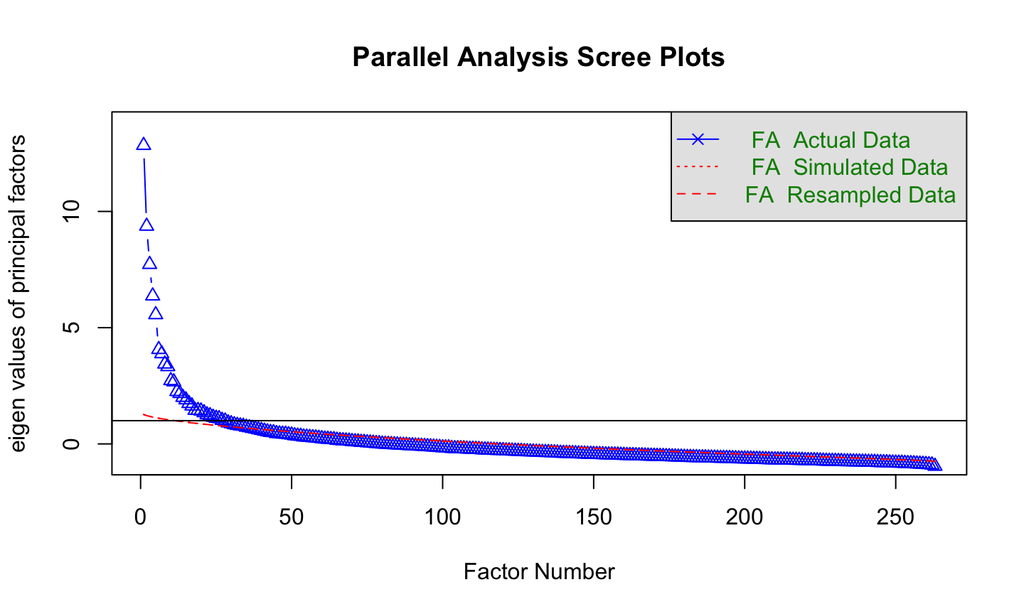

```
## Parallel analysis suggests that the number of factors =  37  and the number of components =  NA
```

```
## [1] 0.02359454
```

```
## [1] 0.7359637
```

```
##      RMSEA      lower      upper confidence
## 0.02894592 0.02488404         NA 0.90000000
```

## EDA

In order to explore Hong Kong people’s values and belief and find out potential factors that lead to the conflicts, there appear to be five main parts for analysis:  
1. Satisfaction with life  
2. Financial situation  
3. Identity  
4. Confidence in the government  
5. Attitude towards democracy

## Satisfaction with life

### Satisfaction.with.your.life :

For Figure 1, 10 means completely satisfied while 1 means completely not satisfied. It shows people are overall satisfied with their life.

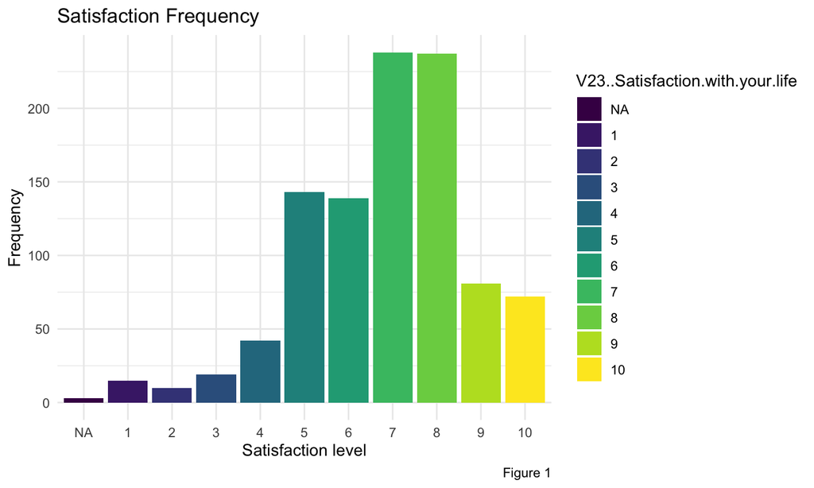

## Satisfaction with life

### Satisfaction.with.your.life by Age:

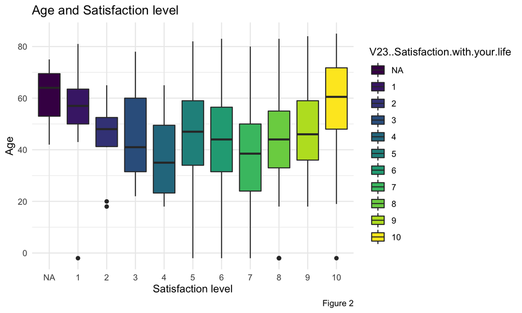

## Satisfaction with life

### Feeling.of.happiness :

Figure 3 shows most people are fairly happy.

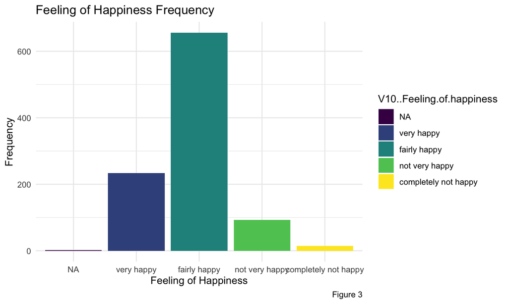

## Satisfaction with life

### Feeling.of.happiness by Age:

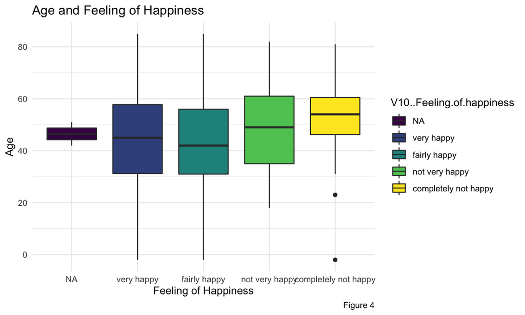

## Satisfaction with life

### How.much.freedom.of.choice.and.control.over.own.life :

For Figure 5, 10 means much freedom to choose while 1 means completely no freedom to choose. It shows people are overall satisfied freedom.

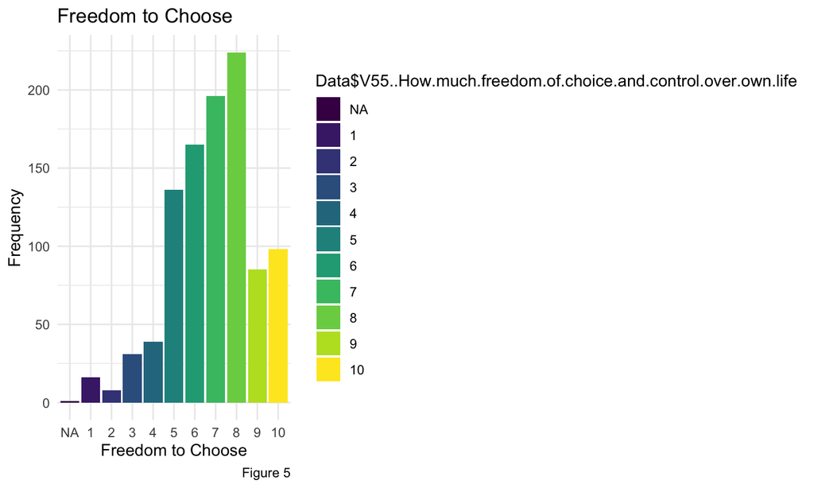

## Satisfaction with life

### How.much.freedom.of.choice.and.control.over.own.life by Age:

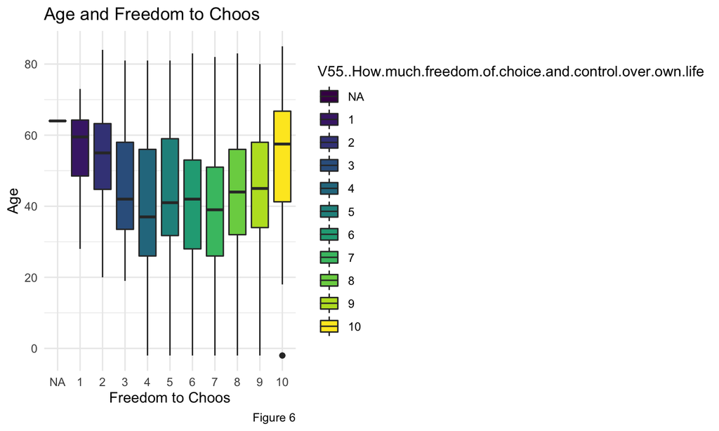

## Financial situation

### Scale.of.incomes :

Figure 7 is in normal distribution form and it is reasonable.

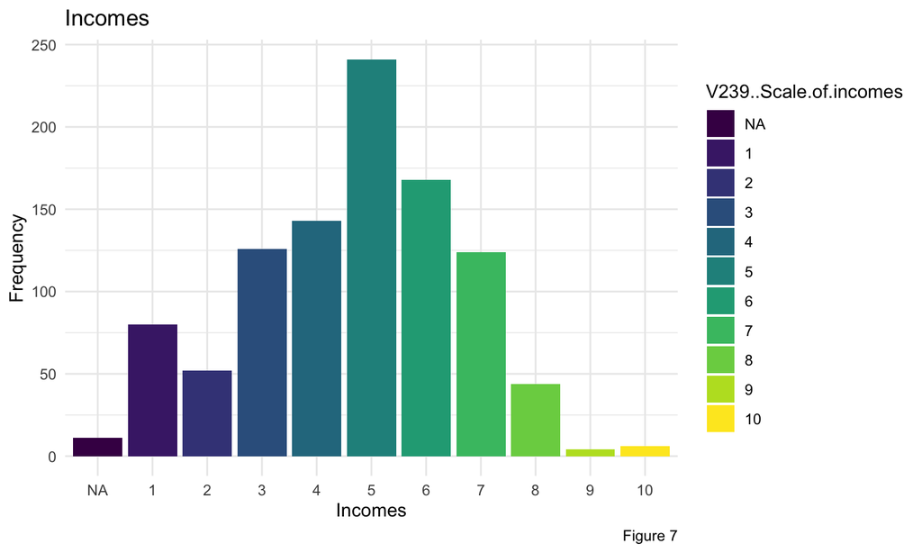

## Financial situation

### Scale.of.incomes by Age:

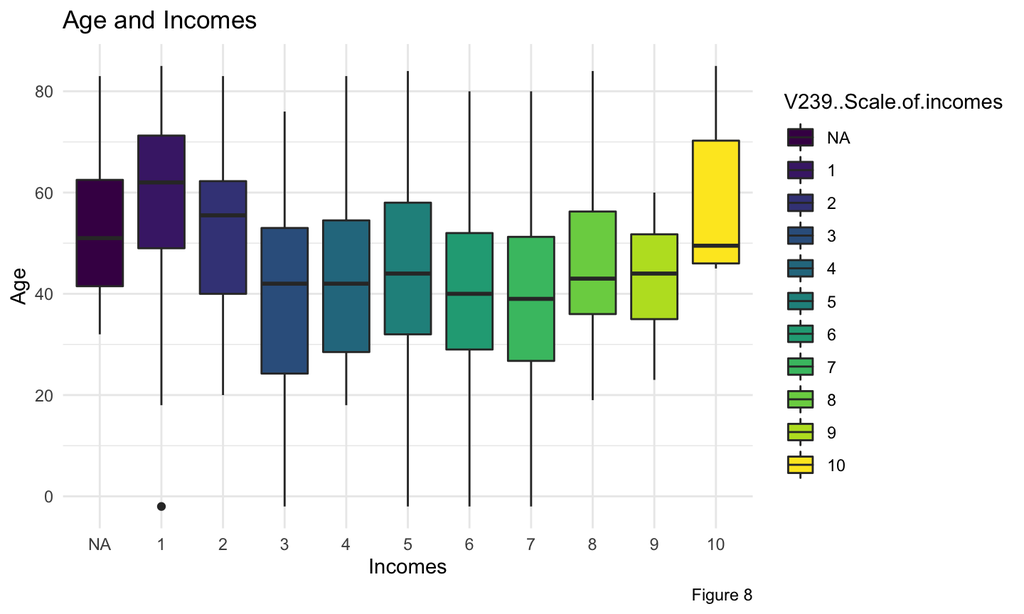

## Financial situation

### Mosaic Plots for Satisfaction with life and Incomes :

It shows people with low income are strongly disatisfied with their life.

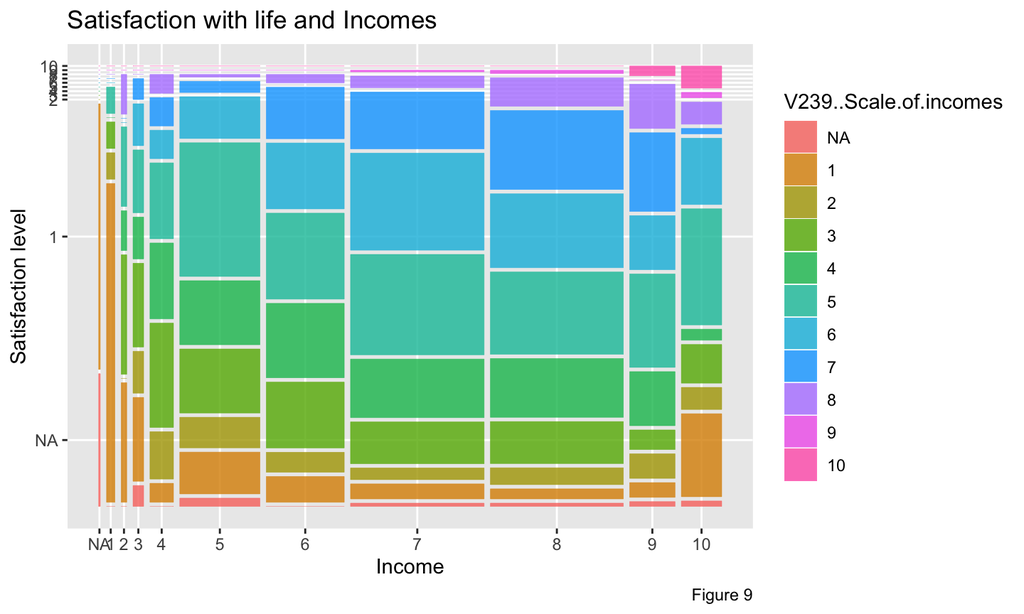

## Financial situation

### Satisfaction.with.financial.situation.of.household :

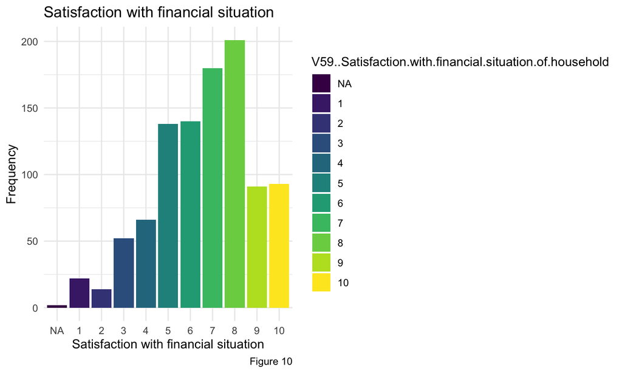

## Financial situation

### Satisfaction.with.financial.situation.of.household by Age:

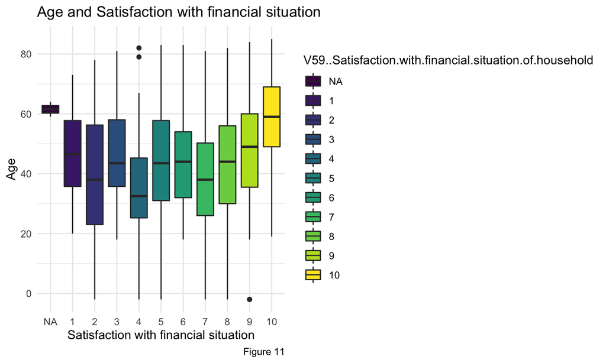

## Financial situation

### Are.you.the.chief.wage.earner.in.your.house :

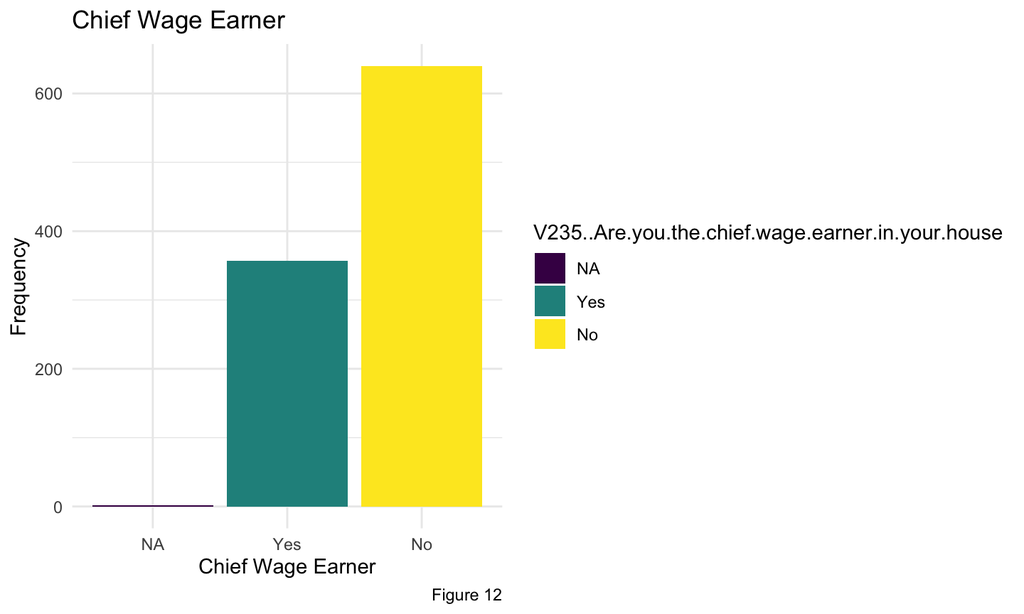

## Financial situation

### Are.you.the.chief.wage.earner.in.your.house by Age:

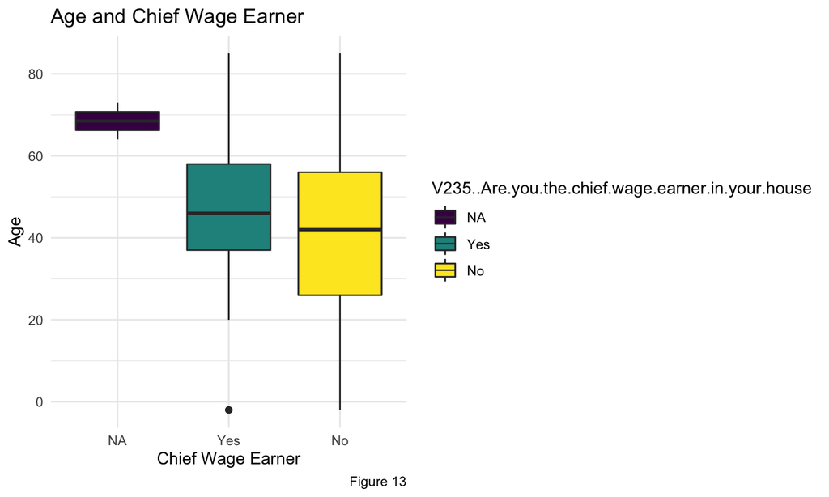

## Financial situation

### Is.the.chief.wage.earner.employed.now.or.not :

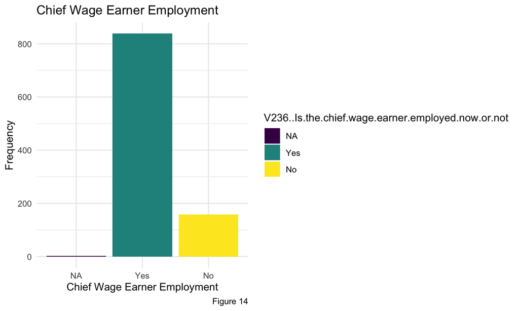

## Financial situation

### Is.the.chief.wage.earner.employed.now.or.not by Age:

It is suprisingly that Figure 15 shows older people have higher unemplotment rate.

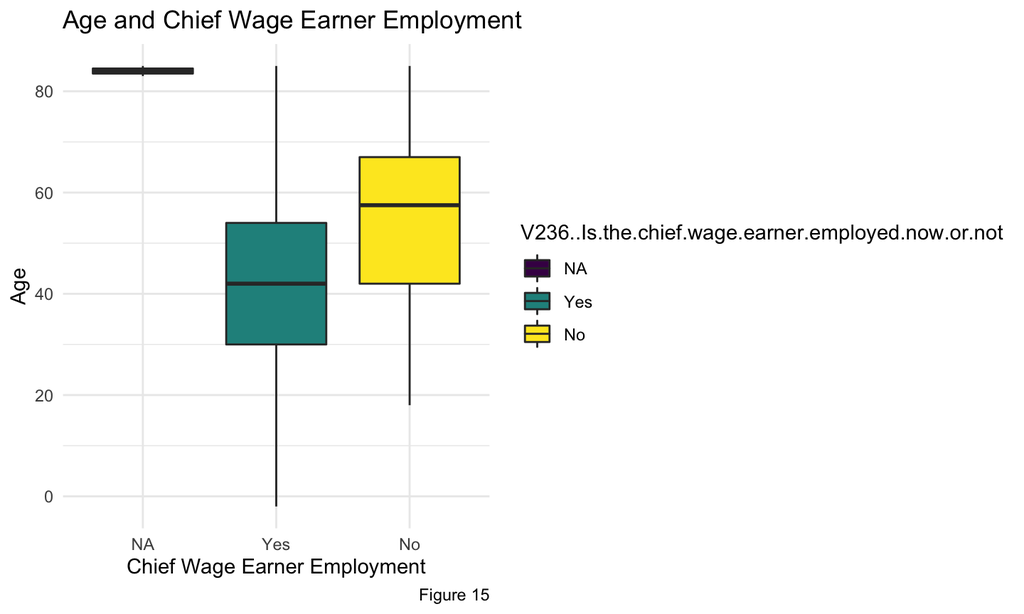

## Financial situation

### Family.savings.during.past.year :

These plots show that Hong Kong people are overall in good financial situation.

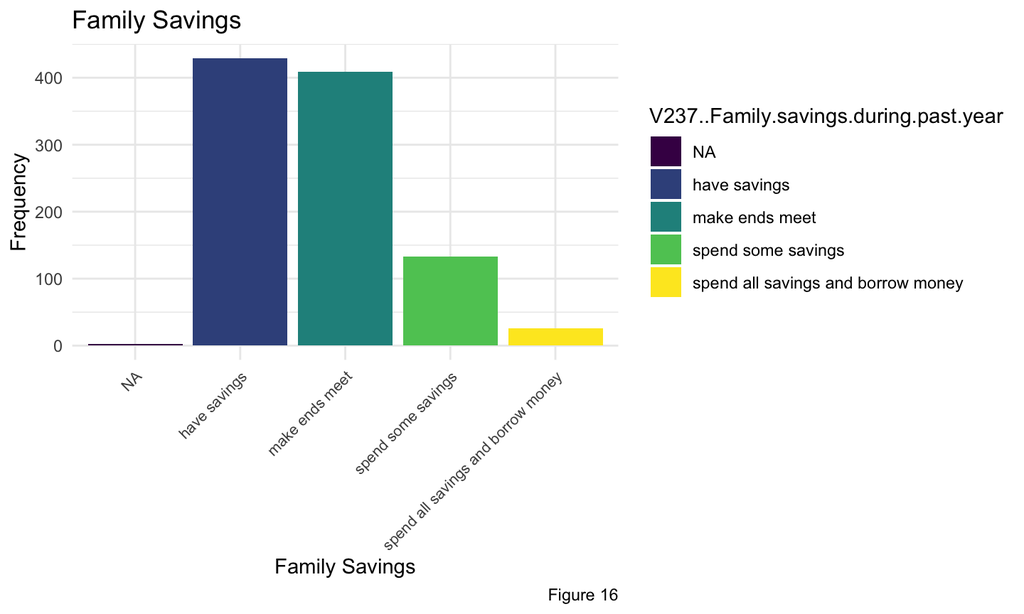

## Financial situation

### Family.savings.during.past.year by Age:

These plots show that Hong Kong people are overall in good financial situation.

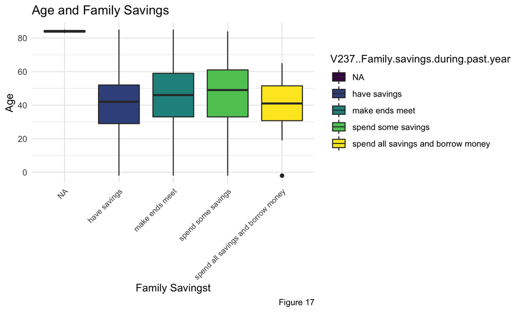

## Identity

### How.proud.of.nationality :

Figure 18 shows people are proud of being a Hong Konger.

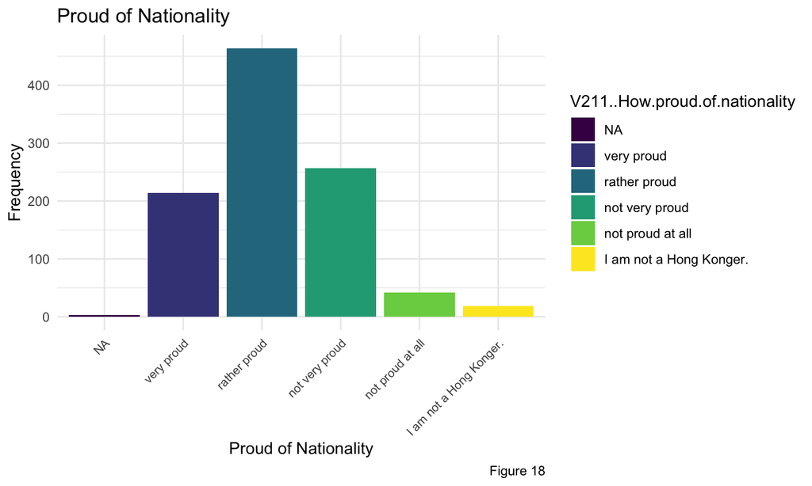

## Identity

### How.proud.of.nationality by Age:

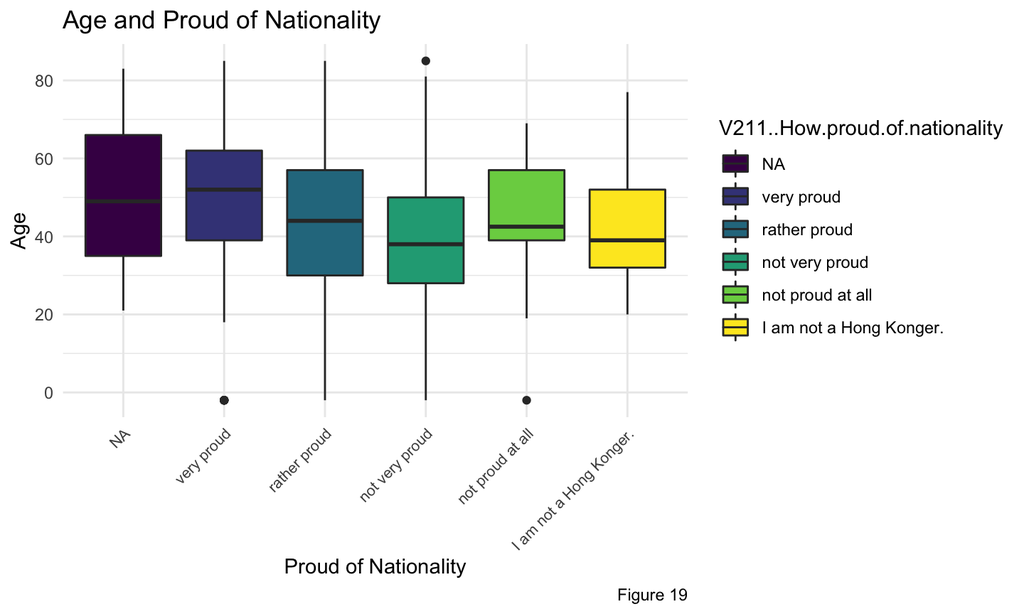

## Identity

### I see myself as a part of the local community, a Hong Konger :

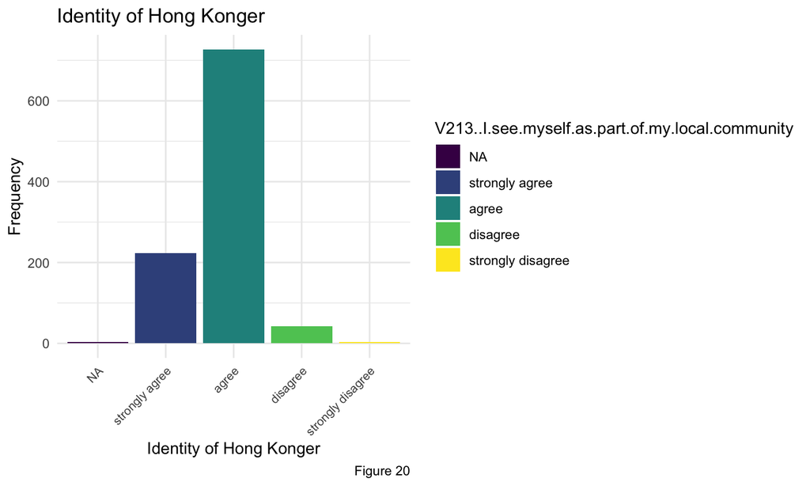

## Identity

### I see myself as a part of the local community, a Hong Konger by Age:

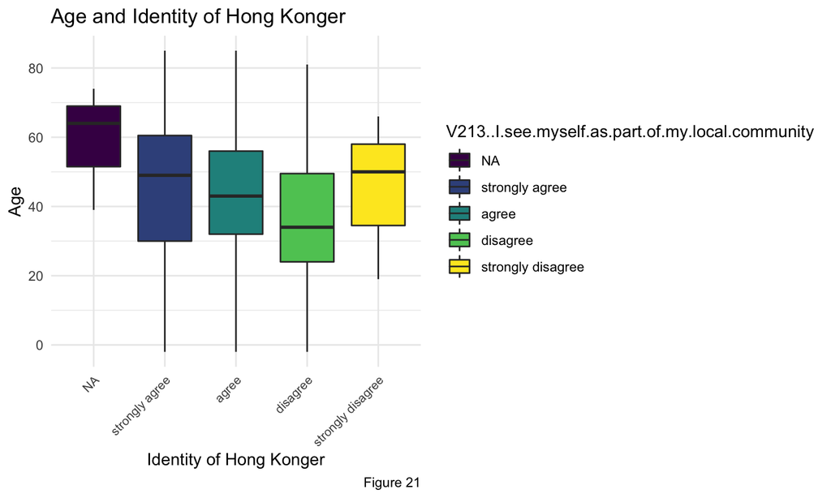

## Identity

### I see myself as a part of the Chinese nation :

It is surprisingly that Figure 22 show most people consider themselves as a part of the Chinese nation.

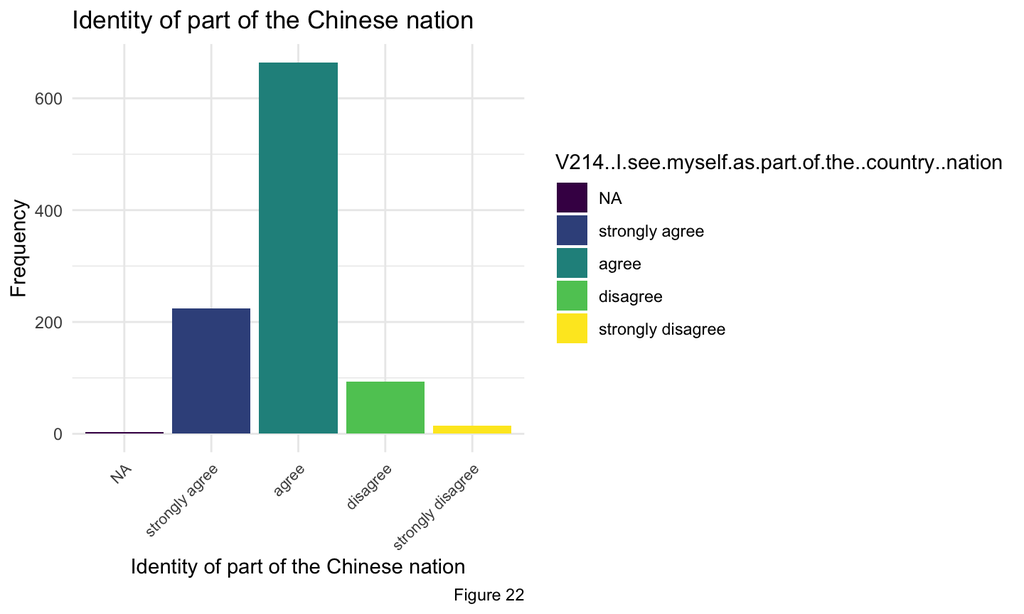

## Identity

### I see myself as a part of the Chinese nation by Age:

Figure 23 shows that younger people are being less considering themselves as a part of the Chinese nation.

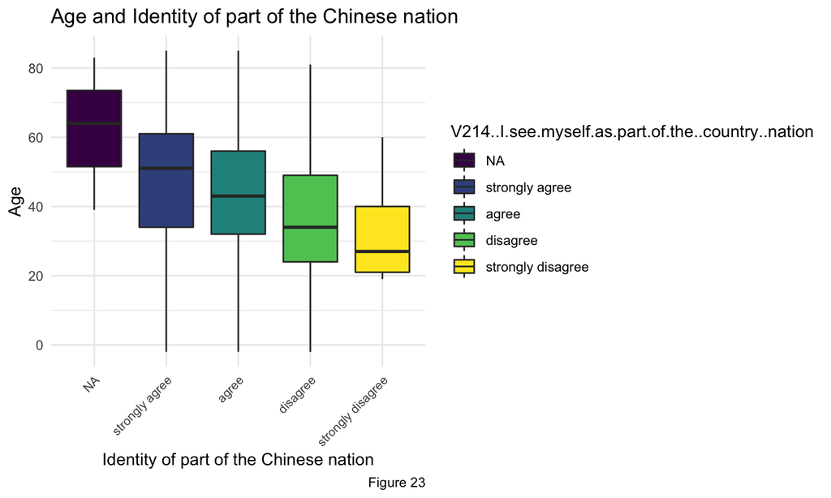

## Confidence in the government

### Confidence..The.police :

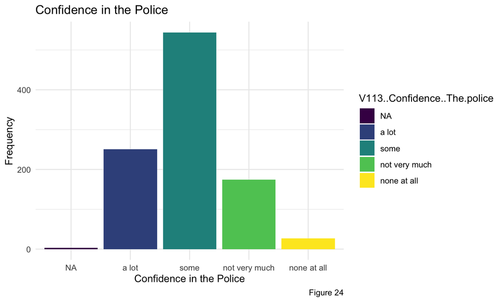

## Confidence in the government

### Confidence..The.police by Age:

Figure 25 shows younger people are significantly have less confidence in the police.

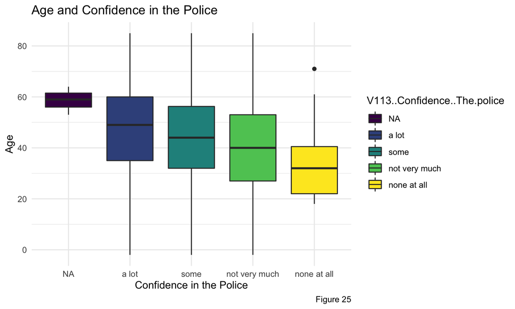

## Confidence in the government

### Confidence..Hong Kong government :

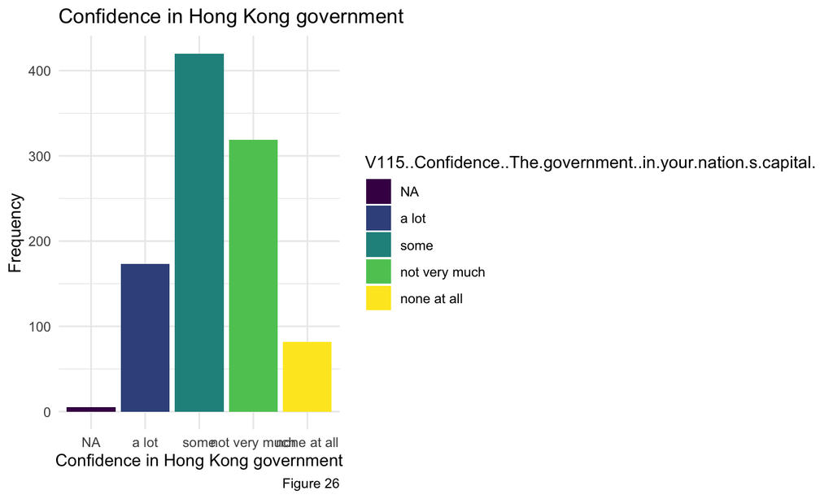

## Confidence in the government

### Confidence..Hong Kong government by Age:

Figure 27 shows younger people are significantly have less confidence in Hong Kong government.

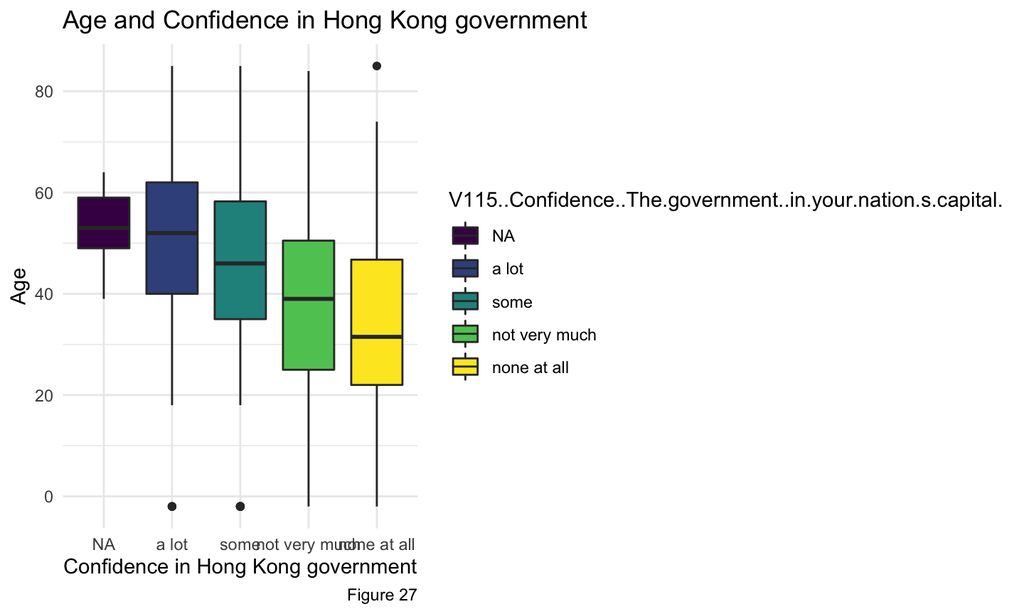

## Confidence in the government

### Confidence..Mainland government :

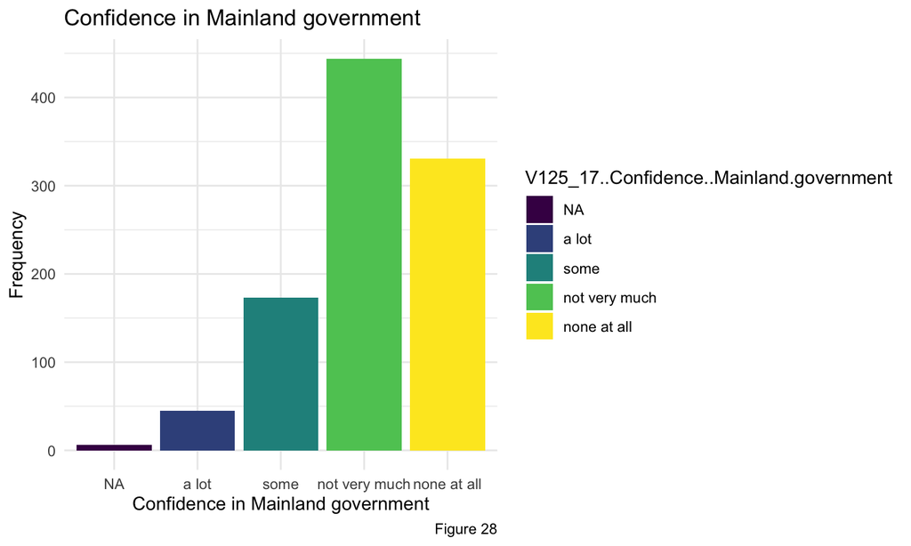

## Confidence in the government

### Confidence..Mainland government by Age:

Figure 29 shows younger people are significantly have less confidence in Mainland government.

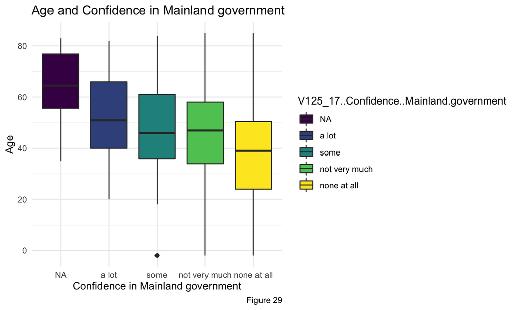

## Attitude towards democracy

### Importance.of.democracy :

For Figure 30, 10 means very important while 1 means not very important. It shows people are overall consider democracy important.

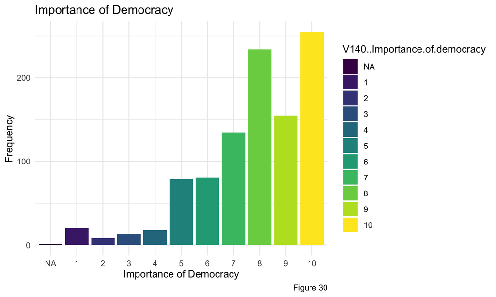